# NeuralNetwork_Bank_Churn

## Bank Churn Prediction

### Objective:

> Given a Bank customer, build a neural network based classifier that can determine whether they will leave or not in the next 6 months.

### Context:

> Businesses like banks which provide service have to worry about problem of 'Churn' i.e. customers leaving and joining another service provider. It is important to understand which aspects of the service influence a customer's decision in this regard. Management can concentrate efforts on improvement of service, keeping in mind these priorities.

### Data Description:

> The case study is from an open-source dataset from Kaggle. The dataset contains 10,000 sample points with 14 distinct features such as CustomerId, CreditScore, Geography, Gender, Age, Tenure, Balance etc. Link to the Kaggle project site: https://www.kaggle.com/barelydedicated/bank-customer-churn-modeling

### Points Distribution:

> The points distribution for this case is as follows:
> 1. Read the dataset
> 2. Drop the columns which are unique for all users like IDs (5 points)
> 3. Distinguish the feature and target set (5 points)
> 4. Divide the data set into training and test sets (5 points)
> 5. Normalize the train and test data (10 points)
> 6. Initialize & build the model. Identify the points of improvement and implement the same the same.(20)
> 7. Predict the results using 0.5 as a threshold (10 points)
> 8. Print the Accuracy score and confusion matrix (5 points)

```python
import pandas as pd
import seaborn as sns
import matplotlib.pyplot as plt
%matplotlib inline

from sklearn import preprocessing
from sklearn.preprocessing import StandardScaler
from sklearn.preprocessing import LabelEncoder, OneHotEncoder
from sklearn.model_selection import train_test_split

from tensorflow.keras.models import Sequential
from tensorflow.keras.layers import Dense
from tensorflow.keras import optimizers
from sklearn.metrics import confusion_matrix
```

```python
from google.colab import drive
drive.mount('/content/drive/')
```

```python
project_path = '/content/drive/My Drive/Tutorial/AIML PGP great learnings/Asset/Project#6-NeuralNetwork/'
dataset_file = project_path+'bank.csv'
```

```python
df=pd.read_csv(dataset_file)
df.shape # Get the dataset shape
```

```
(10000, 14)
```

```python
df.head() #Print first 5 records
```

|  | RowNumber | CustomerId | Surname | CreditScore | Geography | Gender | Age | Tenure | Balance | NumOfProducts | HasCrCard | IsActiveMember | EstimatedSalary | Exited |
| --- | --- | --- | --- | --- | --- | --- | --- | --- | --- | --- | --- | --- | --- | --- |
| 0 | 1 | 15634602 | Hargrave | 619 | France | Female | 42 | 2 | 0.00 | 1 | 1 | 1 | 101348.88 | 1 |
| 1 | 2 | 15647311 | Hill | 608 | Spain | Female | 41 | 1 | 83807.86 | 1 | 0 | 1 | 112542.58 | 0 |
| 2 | 3 | 15619304 | Onio | 502 | France | Female | 42 | 8 | 159660.80 | 3 | 1 | 0 | 113931.57 | 1 |
| 3 | 4 | 15701354 | Boni | 699 | France | Female | 39 | 1 | 0.00 | 2 | 0 | 0 | 93826.63 | 0 |
| 4 | 5 | 15737888 | Mitchell | 850 | Spain | Female | 43 | 2 | 125510.82 | 1 | 1 | 1 | 79084.10 | 0 |

### EDA

##### Drop the unwanted/unique columns

In this dataset, the following columns has unique data which wouldn't be useful for model building, let's drop it

1. RowNumber
2. Customer ID

```python
df.drop(columns=['RowNumber','CustomerId'], axis=1, inplace=True)
df.shape # Dataset shape after the dropcolumn
```

```
(10000, 12)
```

```python
df.info() # Print information about the dataset
```

```
<class 'pandas.core.frame.DataFrame'>
RangeIndex: 10000 entries, 0 to 9999
Data columns (total 12 columns):
 #   Column           Non-Null Count  Dtype
---  ------           --------------  -----
 0   Surname          10000 non-null  object
 1   CreditScore      10000 non-null  int64
 2   Geography        10000 non-null  object
 3   Gender           10000 non-null  object
 4   Age              10000 non-null  int64
 5   Tenure           10000 non-null  int64
 6   Balance          10000 non-null  float64
 7   NumOfProducts    10000 non-null  int64
 8   HasCrCard        10000 non-null  int64
 9   IsActiveMember   10000 non-null  int64
 10  EstimatedSalary  10000 non-null  float64
 11  Exited           10000 non-null  int64
dtypes: float64(2), int64(7), object(3)
memory usage: 937.6+ KB
```

```python
df.describe().T # Print the description about the dataset
```

|  | count | mean | std | min | 25% | 50% | 75% | max |
| --- | --- | --- | --- | --- | --- | --- | --- | --- |
| CreditScore | 10000.0 | 650.528800 | 96.653299 | 350.00 | 584.00 | 652.000 | 718.0000 | 850.00 |
| Age | 10000.0 | 38.921800 | 10.487806 | 18.00 | 32.00 | 37.000 | 44.0000 | 92.00 |
| Tenure | 10000.0 | 5.012800 | 2.892174 | 0.00 | 3.00 | 5.000 | 7.0000 | 10.00 |
| Balance | 10000.0 | 76485.889288 | 62397.405202 | 0.00 | 0.00 | 97198.540 | 127644.2400 | 250898.09 |
| NumOfProducts | 10000.0 | 1.530200 | 0.581654 | 1.00 | 1.00 | 1.000 | 2.0000 | 4.00 |
| HasCrCard | 10000.0 | 0.705500 | 0.455840 | 0.00 | 0.00 | 1.000 | 1.0000 | 1.00 |
| IsActiveMember | 10000.0 | 0.515100 | 0.499797 | 0.00 | 0.00 | 1.000 | 1.0000 | 1.00 |
| EstimatedSalary | 10000.0 | 100090.239881 | 57510.492818 | 11.58 | 51002.11 | 100193.915 | 149388.2475 | 199992.48 |
| Exited | 10000.0 | 0.203700 | 0.402769 | 0.00 | 0.00 | 0.000 | 0.0000 | 1.00 |

```python
df.isnull().sum()
# There is no null value in the dataset
```

```
Surname            0
CreditScore        0
Geography          0
Gender             0
Age                0
Tenure             0
Balance            0
NumOfProducts      0
HasCrCard          0
IsActiveMember     0
EstimatedSalary    0
Exited             0
dtype: int64
```

```python
print("Value counts:\n",df['Exited'].value_counts())
print("Value counts in percentage:\n", df['Exited'].value_counts(normalize=True)*100)
```

```
Value counts:
 0    7963
1    2037
Name: Exited, dtype: int64
Value counts in percentage:
 0    79.63
1    20.37
Name: Exited, dtype: float64
```

This is an imbalanced dataset since the target column is distributed as 80%-20%

#### Visualizing the Data

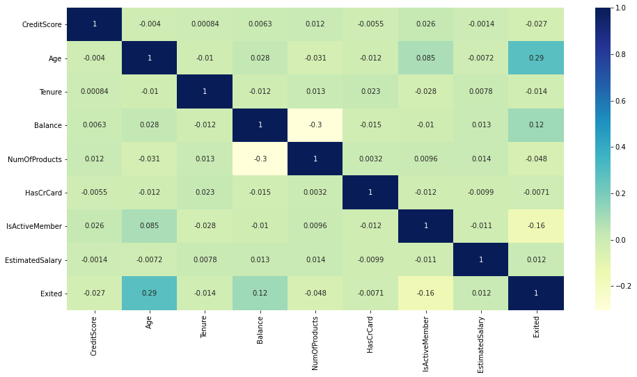

```python
plt.figure(figsize=(16,8))
sns.heatmap(data=df.corr(method='pearson', min_periods=1), cmap='YlGnBu', annot=True,)
```

[output not shown]

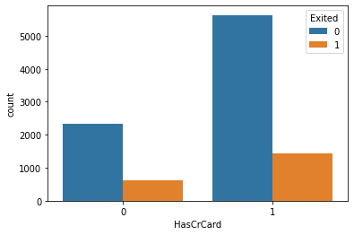

```python
print('Exited Customers based on HasCreditCard', sns.countplot(x=df['HasCrCard'], hue=df['Exited'], linewidth=2))
```

```
Customer Estimated Salary: AxesSubplot(0.125,0.125;0.775x0.755)
```

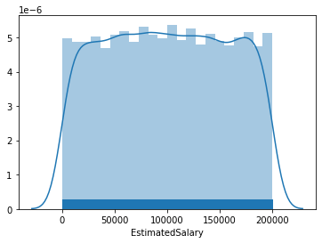

```python
print('Customer Estimated Salary:', sns.distplot(df['EstimatedSalary'], rug=True))
```

```
Customer Balance: AxesSubplot(0.125,0.125;0.775x0.755)
```

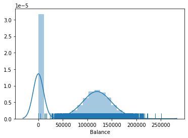

```python
print('Customer Balance:', sns.distplot(df['Balance'], rug=True))
```

```
Customer age group: AxesSubplot(0.125,0.125;0.775x0.755)
```

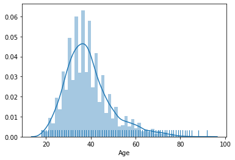

```python
print('Customer age group:', sns.distplot(df['Age'], rug=True))
```

```
11.58 199992.48
Customer Estimated salary with Gender: AxesSubplot(0.125,0.125;0.775x0.755)
```

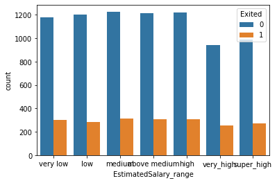

```python
def binning(col, cut_points, label):
    minval = col.min()
    maxval = col.max()
    print(minval, maxval)

    break_points = [minval]+ cut_points+[maxval]
    colBin = pd.cut(col, bins = break_points, labels=label, include_lowest=True)
    return colBin

# cut_bins = [25000, 50000, 75000, 100000,125000,150000]
cut_bins = [30000, 60000, 90000, 120000, 150000, 175000]
labels = ['very low','low','medium','above medium','high','very_high','super_high']
df['EstimatedSalary_range'] = binning(df['EstimatedSalary'], cut_bins, labels)
df['EstimatedSalary_range'].value_counts()

print('Customer Estimated salary with Gender:', sns.countplot(df['EstimatedSalary_range'], hue=df['Exited'], linewidth=2))
df.drop('EstimatedSalary_range', axis=1, inplace=True) # Remove newly created column
```

```
Exited Customers based on Gender AxesSubplot(0.125,0.125;0.775x0.755)
```

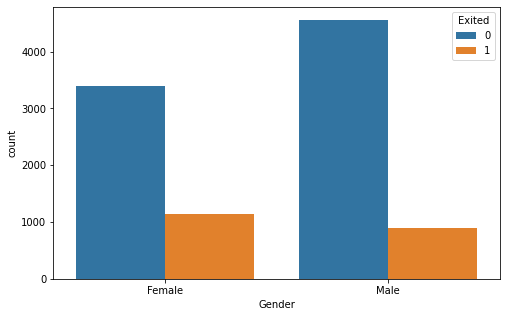

```python
plt.figure(figsize=(8,5))
print('Exited Customers based on Gender', sns.countplot(df['Gender'], hue=df['Exited'], linewidth=2))
```

```python
# total_in_active = len(df[df['IsActiveMember']==0])
# total_in_inactive = len(df[df['IsActiveMember']==1])
# total_in_active, total_in_inactive
# df[df['IsActiveMember']== df['Exited']]

active_but_exited = len(df[ (df['IsActiveMember']==0) & (df['Exited']==1) ])
inactive_and_exited = len(df[ (df['IsActiveMember']==1) & (df['Exited']==1) ])
active_and_not_exited = len(df[ (df['IsActiveMember']==0) & (df['Exited']==0) ])
inactive_and_not_exited = len(df[ (df['IsActiveMember']==1) & (df['Exited']==0) ])


total_exited = len(df[df['Exited']==1])
total_not_exited = len(df[df['Exited']==0])

print('Customer exited but active percentage: {:.2f}%'.format((active_but_exited/total_exited)*100))
print('Customer exited but not active percentage: {:.2f}%'.format((inactive_and_exited/total_exited)*100))

print('Customer not exited and active percentage: {:.2f}%'.format((active_and_not_exited/total_not_exited)*100))
print('Customer not exited but not active percentage: {:.2f}%'.format((inactive_and_not_exited/total_not_exited)*100))
```

```
Customer exited but active percentage: 63.92%
Customer exited but not active percentage: 36.08%
Customer not exited and active percentage: 44.54%
Customer not exited but not active percentage: 55.46%
```

```python
print('Customer exited but not active count:', inactive_and_exited)
```

```
Customer exited but not active count: 735
```

### Data Encoding and Train/Test Split

```python
# Get Target column
X = df.drop(['Exited','Surname'], axis=1)
y = df[['Exited']]
X.shape, y.shape
```

```
((10000, 10), (10000, 1))
```

```python
# Convert the categorical data (Geography and Gender) to numeric by adding OneHotEncoder
# label = LabelEncoder()
# X['Geography'] = label.fit_transform(X['Geography'])
# X['Gender'] = label.fit_transform(X['Gender'])
# onehotencoding = OneHotEncoder()
# X = onehotencoding.fit_transform(X).toarray()
```

```python
X = pd.get_dummies(X)
X.head()
```

|  | CreditScore | Age | Tenure | Balance | NumOfProducts | HasCrCard | IsActiveMember | EstimatedSalary | Geography_France | Geography_Germany | Geography_Spain | Gender_Female | Gender_Male |
| --- | --- | --- | --- | --- | --- | --- | --- | --- | --- | --- | --- | --- | --- |
| 0 | 619 | 42 | 2 | 0.00 | 1 | 1 | 1 | 101348.88 | 1 | 0 | 0 | 1 | 0 |
| 1 | 608 | 41 | 1 | 83807.86 | 1 | 0 | 1 | 112542.58 | 0 | 0 | 1 | 1 | 0 |
| 2 | 502 | 42 | 8 | 159660.80 | 3 | 1 | 0 | 113931.57 | 1 | 0 | 0 | 1 | 0 |
| 3 | 699 | 39 | 1 | 0.00 | 2 | 0 | 0 | 93826.63 | 1 | 0 | 0 | 1 | 0 |
| 4 | 850 | 43 | 2 | 125510.82 | 1 | 1 | 1 | 79084.10 | 0 | 0 | 1 | 1 | 0 |

```python
X_train, X_test, y_train, y_test = train_test_split(X, y, test_size = 0.2, random_state = 0)
X_train.shape, X_test.shape, y_train.shape, y_test.shape
```

```
((8000, 13), (2000, 13), (8000, 1), (2000, 1))
```

```python
sc = StandardScaler()
X_train = sc.fit_transform(X_train)
X_test = sc.transform(X_test)

# X_train = preprocessing.normalize(X_train)
# X_test = preprocessing.normalize(X_test)

X_train.shape, X_test.shape
```

```
((8000, 13), (2000, 13))
```

### Building Artifical Neural Network

```python
def build_model():
  model = Sequential()

  # Create layer
  model.add(Dense(64, input_shape=(13,), activation='relu')) #Input layer
  model.add(Dense(32, activation='tanh')) # Hidden layer
  model.add(Dense(1, activation='sigmoid')) # Output layer

  # Learning rate
  sgd = optimizers.RMSprop(0.01) #RMSprop

  model.compile(optimizer=sgd, loss='binary_crossentropy', metrics=['accuracy']) # Loss = mean_squared_error
  model.summary()
  return model

model = build_model()
```

```
Model: "sequential_21"
_________________________________________________________________
Layer (type)                 Output Shape              Param #
=================================================================
dense_67 (Dense)             (None, 64)                896
_________________________________________________________________
dense_68 (Dense)             (None, 32)                2080
_________________________________________________________________
dense_69 (Dense)             (None, 1)                 33
=================================================================
Total params: 3,009
Trainable params: 3,009
Non-trainable params: 0
_________________________________________________________________
```

```python
history = model.fit(X_train, y_train.values, validation_split = 0.2, batch_size=500, epochs=20, verbose=1)
```

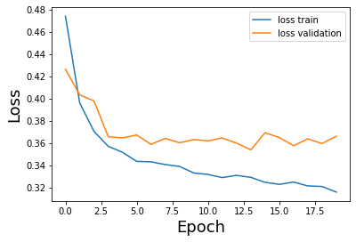

```python
plt.plot(history.history['loss'])
plt.plot(history.history['val_loss'])
plt.xlabel('Epoch', fontsize=18)
plt.ylabel(r'Loss', fontsize=18)
plt.legend(('loss train','loss validation'), loc=0)
```

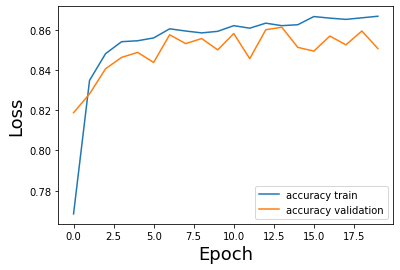

```python
plt.plot(history.history['accuracy'])
plt.plot(history.history['val_accuracy'])
plt.xlabel('Epoch', fontsize=18)
plt.ylabel(r'Loss', fontsize=18)
plt.legend(('accuracy train','accuracy validation'), loc=0)
```

```python
def build_model():
  model = Sequential()

  # Create layer
  model.add(Dense(64, input_shape=(13,), activation='relu')) #Input layer
  model.add(Dense(32, activation='tanh')) # Hidden layer
  model.add(Dense(1, activation='sigmoid')) # Output layer

  # Learning rate
  sgd = optimizers.Adam(0.01) #Adam(lr=0.01)

  model.compile(optimizer=sgd, loss='binary_crossentropy', metrics=['accuracy']) # Loss = mean_squared_error
  model.summary()
  return model


model_1 = build_model()
```

```
Model: "sequential_27"
_________________________________________________________________
Layer (type)                 Output Shape              Param #
=================================================================
dense_82 (Dense)             (None, 64)                896
_________________________________________________________________
dense_83 (Dense)             (None, 32)                2080
_________________________________________________________________
dense_84 (Dense)             (None, 1)                 33
=================================================================
Total params: 3,009
Trainable params: 3,009
Non-trainable params: 0
_________________________________________________________________
```

```python
model_1_history = model_1.fit(X_train, y_train.values, validation_split = 0.2, batch_size=500, epochs=12, verbose=1)
```

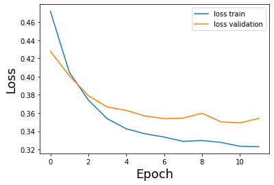

```python
plt.plot(model_1_history.history['loss'])
plt.plot(model_1_history.history['val_loss'])
plt.xlabel('Epoch', fontsize=18)
plt.ylabel(r'Loss', fontsize=18)
plt.legend(('loss train','loss validation'), loc=0)
```

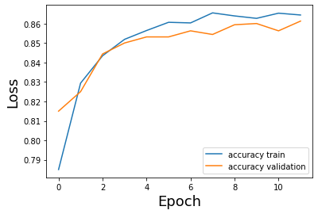

```python
# Print accuracy
plt.plot(model_1_history.history['accuracy'])
plt.plot(model_1_history.history['val_accuracy'])
plt.xlabel('Epoch', fontsize=18)
plt.ylabel(r'Loss', fontsize=18)
plt.legend(('accuracy train','accuracy validation'), loc=0)
```

#### The find tuned model is doing good compare with previous model, the accuracy has been improved to 86%.

#### Predict the results using 0.5 as a threshold

```python
y_pred = model.predict(X_test)
y_pred = (y_pred > 0.5)
print('Prediction:', y_pred)
```

```
Prediction: [[False]
 [False]
 [False]
 ...
 [False]
 [False]
 [False]]
```

```python
print('Prediction value counts:\n', pd.DataFrame(y_pred)[0].value_counts())
print('Target values count:\n', y_test['Exited'].value_counts())
```

```
Prediction value counts:
 False    1786
True      214
Name: 0, dtype: int64
Target values count:
 0    1595
1     405
Name: Exited, dtype: int64
```

```python
# Let's check the prediction in confusion matrix
cmatrix = confusion_matrix(y_test.values, y_pred)
print(cmatrix)
```

```
[[1552   43]
 [ 234  171]]
```

The accuracy from confusion matrix, accuracy = (TP+TN)/(TP+TN+FP+FN) accuracy = (1552+171)/(1552+43+234+171) => 0.86

```python
loss, accuracy = model_1.evaluate(X_test, y_test.values)
print('Test accuracy: {:.2f}'.format(accuracy))
```

```
Test accuracy: 0.86
```